# GLM para dados binomiais

Gabriela Neres, Mariane Melo, Pedro Lopes

## 1 Introdução

Os coalas (*Phascolarctos cinereus*) vêm sofrendo declínios populacionais devido à desflorestação, degradação de habitat, doenças, incêndios florestais e urbanização. Mais de 50% das florestas originais de eucalipto foram desmatadas para agricultura e desenvolvimento urbano, tornando crucial a compreensão dos fatores que influenciam sua distribuição.

Este estudo utiliza dados de 300 locais em Noosa (Austrália) para investigar como a porcentagem de árvores primárias e secundárias (espécies preferidas para alimentação) influencia a presença/ausência de coalas. O objetivo é ajustar modelos binomiais (GLM) para identificar se a presença de **árvores primárias** e/ou **árvores secundárias** melhor predizem a ocorrência da espécie.

## 2 Carregando os pacotes utilizados

```r
library(ggplot2)      # Criação de gráficos e visualizações
library(dplyr)        # Manipulação e transformação de dados
library(DHARMa)       # Diagnóstico de resíduos de modelos GLM
library(performance)  # Avaliação de desempenho de modelos
library(effects)      # Visualização de efeitos marginais
library(ggpubr)       # Combinação e organização de múltiplos gráficos
```

## 3 Importação dos dados

```r
dados <- readRDS("Dados/koalas.rds")

# Visualizar a estrutura dos dados
str(dados)
```

```
## 'data.frame':    301 obs. of  22 variables:
##  $ V1 : chr  "site" "1" "1" "1" ...
##  $ V2 : chr  "subsite" "1" "2" "3" ...
##  $ V3 : chr  "easting" "510396" "510356" "510329" ...
##  $ V4 : chr  "northing" "7081160" "7081052" "7080920" ...
##  $ V5 : chr  "presence" "1" "1" "1" ...
##  $ V6 : chr  "pprim_ssite" "0.00" "0.00" "0.00" ...
##  $ V7 : chr  "psec_ssite" "20.00" "15.00" "0.00" ...
##  $ V8 : chr  "phss_5km" "9.55" "9.88" "10.08" ...
##  $ V9 : chr  "phss_2.5km" "2.27" "2.56" "2.85" ...
##  $ V10: chr  "phss_1km" "7.58" "8.90" "9.61" ...
##  $ V11: chr  "pm_5km" "12.86" "12.90" "13.00" ...
##  $ V12: chr  "pm_2.5km" "26.84" "27.15" "27.50" ...
##  $ V13: chr  "pm_1km" "86.76" "85.39" "84.59" ...
##  $ V14: chr  "pdens_5km" "0.30" "0.30" "0.29" ...
##  $ V15: chr  "pdens_2.5km" "0.25" "0.25" "0.41" ...
##  $ V16: chr  "pdens_1km" "0.64" "1.59" "0.95" ...
##  $ V17: chr  "edens_5km" "13.67" "13.75" "13.85" ...
##  $ V18: chr  "edens_2.5km" "15.36" "15.78" "16.50" ...
##  $ V19: chr  "edens_1km" "14.36" "12.41" "13.26" ...
##  $ V20: chr  "rdens_5km" "310.40" "321.27" "325.83" ...
##  $ V21: chr  "rdens_2.5km" "280.74" "307.73" "337.16" ...
##  $ V22: chr  "rdens_1km" "32.91" "48.91" "44.38" ...
```

## 4 Preparação dos dados

```r
# Extrair a primeira linha como nomes das colunas
nomes_col <- as.character(dados[1, ])

# Remover a primeira linha (que agora será o cabeçalho)
dados <- dados[-1, ]

# Atribuir os nomes corretos
colnames(dados) <- nomes_col

# Convertendo as variáveis
dados[, nomes_col] <- lapply(dados[, nomes_col], as.numeric)

# Verificar a estrutura final
str(dados)
```

```
## 'data.frame':    300 obs. of  22 variables:
##  $ site       : num  1 1 1 2 2 2 3 3 3 4 ...
##  $ subsite    : num  1 2 3 4 5 6 7 8 9 10 ...
##  $ easting    : num  510396 510356 510329 509556 509587 ...
##  $ northing   : num  7081160 7081052 7080920 7080313 7080192 ...
##  $ presence   : num  1 1 1 1 1 1 1 1 1 0 ...
##  $ pprim_ssite: num  0 0 0 0 0 0 0 0 0 0 ...
##  $ psec_ssite : num  20 15 0 5 15 15 0 0 0 0 ...
##  $ phss_5km   : num  9.55 9.88 10.08 13.8 13.64 ...
##  $ phss_2.5km : num  2.27 2.56 2.85 6.45 6.9 ...
##  $ phss_1km   : num  7.58 8.9 9.61 9.04 9.76 ...
##  $ pm_5km     : num  12.9 12.9 13 14.1 14.2 ...
##  $ pm_2.5km   : num  26.8 27.1 27.5 30.6 30.7 ...
##  $ pm_1km     : num  86.8 85.4 84.6 56.9 55.8 ...
##  $ pdens_5km  : num  0.3 0.3 0.29 0.32 0.33 0.33 0.31 0.32 0.31 0.32 ...
##  $ pdens_2.5km: num  0.25 0.25 0.41 0.61 0.71 0.61 0.25 0.15 0.2 0.2 ...
##  $ pdens_1km  : num  0.64 1.59 0.95 1.91 1.91 1.27 0.64 0.64 0.64 0.32 ...
##  $ edens_5km  : num  13.7 13.8 13.8 15.5 15.7 ...
##  $ edens_2.5km: num  15.4 15.8 16.5 26 26.4 ...
##  $ edens_1km  : num  14.4 12.4 13.3 36.4 33.9 ...
##  $ rdens_5km  : num  310 321 326 476 472 ...
##  $ rdens_2.5km: num  281 308 337 539 560 ...
##  $ rdens_1km  : num  32.9 48.9 44.4 839.5 889.2 ...
```

## 5 Análise exploratória

### 5.1 Distribuição da variável resposta

```r
table(dados$presence)
```

```
##
##   0   1
## 186 114
```

A variável resposta é binária (presença = 1, ausência = 0). Também podemos observar esses valores através de proporção.

```r
prop_table <- dados %>%
  group_by(presence) %>%
  summarise(Ncoalas = n()) %>%
  mutate(Proporção = Ncoalas / sum(Ncoalas))
prop_table
```

```
## # A tibble: 2 × 3
##   presence Ncoalas Proporção
##      <dbl>   <int>     <dbl>
## 1        0     186      0.62
## 2        1     114      0.38
```

Os resultados mostram que em 38% dos locais amostrados foram encontrados coalas, enquanto em 62% não houve registros da espécie.

### 5.2 Relação com árvores primárias e secundárias

As árvores primárias são as espécies preferidas para a alimentação dos coalas.

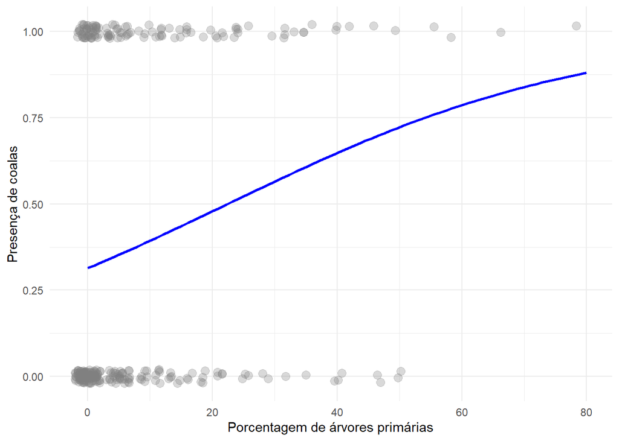

```r
# Gráfico para árvores primárias
ggplot(dados, aes(x = pprim_ssite, y = presence)) +
  geom_point(size = 3, col = 'gray50', alpha = 0.3, position = position_jitter(height = 0.02)) +
  geom_smooth(method = "glm",
              method.args = list(family = "binomial"),
              color = "blue",
              se = FALSE,
              alpha = 0.3) +
  theme_minimal() +
  labs(x = "Porcentagem de árvores primárias",
       y = "Presença de coalas")
```

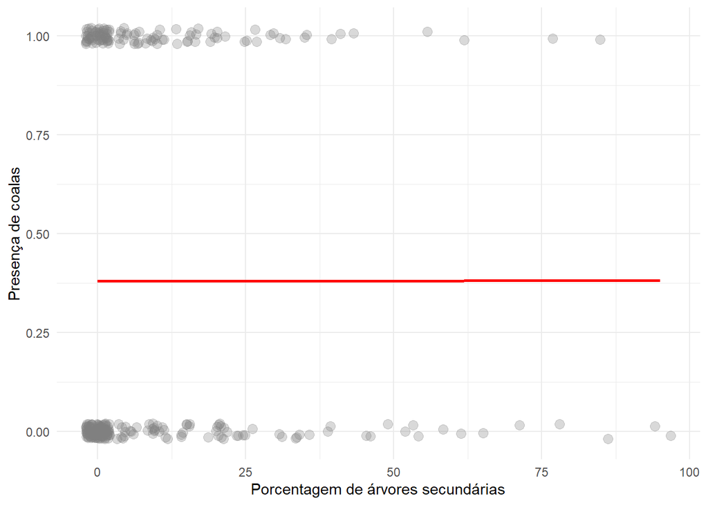

```r
# Gráfico para árvores secundárias
ggplot(dados, aes(x = psec_ssite, y = presence)) +
  geom_point(size = 3, col = 'gray50', alpha = 0.3, position = position_jitter(height = 0.02)) +
  geom_smooth(method = "glm",
              method.args = list(family = "binomial"),
              color = "red",
              se = FALSE,
              alpha = 0.3) +
  theme_minimal() +
  labs(x = "Porcentagem de árvores secundárias",
       y = "Presença de coalas")
```

Através da análise visual dos gráficos gerados, podemos ver que a presença dos coalas possui uma relação positiva com as árvores primárias, enquanto que essa relação com as árvores secundárias parece mais fraca, apresentando uma curva quase plana.

### 5.3 Comparação entre presença/ausência

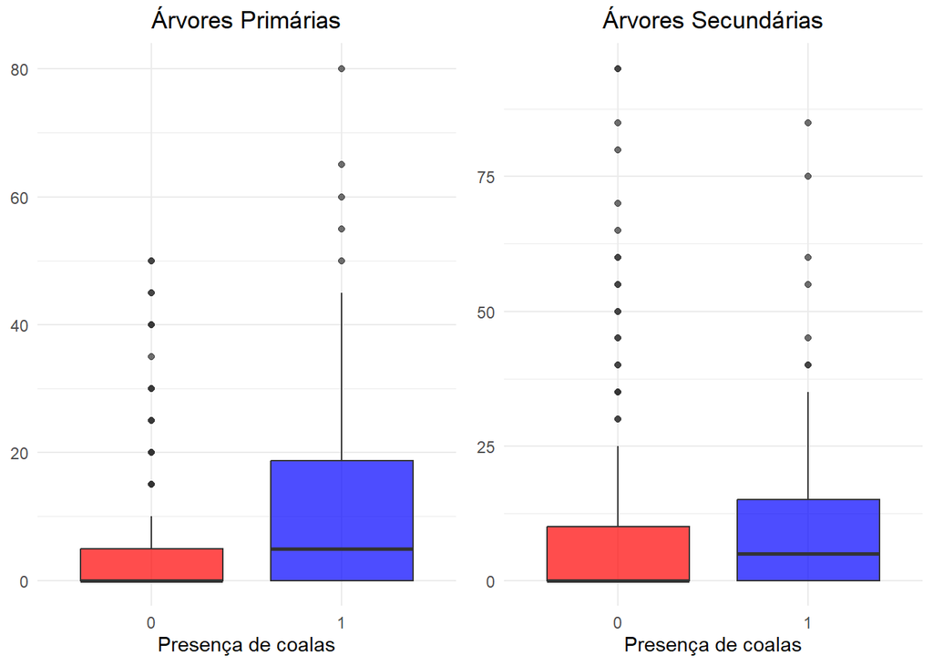

```r
# Boxplot para árvores primárias
p1 <- ggplot(dados, aes(x = factor(presence), y = pprim_ssite, fill = factor(presence))) +
  geom_boxplot(alpha = 0.7) +
  scale_fill_manual(values = c("0" = "red", "1" = "blue")) +
  labs(x = "Presença de coalas",
       y = NULL,
       title = "Árvores Primárias") +
  theme_minimal() +
  theme(legend.position = "none",
        plot.title = element_text(hjust = 0.5))

# Boxplot para árvores secundárias
p2 <- ggplot(dados, aes(x = factor(presence), y = psec_ssite, fill = factor(presence))) +
  geom_boxplot(alpha = 0.7) +
  scale_fill_manual(values = c("0" = "red", "1" = "blue")) +
  labs(x = "Presença de coalas",
       y = NULL,
       title = "Árvores Secundárias") +
  theme_minimal() +
  theme(legend.position = "none",
        plot.title = element_text(hjust = 0.5))

ggarrange(p1, p2, ncol = 2)
```

### 5.4 Verificar correlação entre variáveis preditoras

```r
cor(dados$pprim_ssite, dados$psec_ssite, use = "complete.obs")
```

```
## [1] -0.1484031
```

O resultado mostrou uma correlação negativa fraca entre as variáveis, o que indica a independência entre elas.

## 6 Ajuste dos modelos GLM

Iremos ajustar 4 modelos, sendo eles:

- **Modelo Nulo**, que não considera nenhuma das variáveis;
- **Modelo com árvores primárias**;
- **Modelo com árvores secundárias**;
- **Modelo completo**, com ambas as variáveis.

```r
# Nulo
mod0 <- glm(presence ~ 1,
            family = binomial(link = "logit"),
            data = dados)

# Árvores primárias
mod1 <- glm(presence ~ pprim_ssite,
            family = binomial(link = "logit"),
            data = dados)

# Árvores secundárias
mod2 <- glm(presence ~ psec_ssite,
            family = binomial(link = "logit"),
            data = dados)

# Completo
mod3 <- glm(presence ~ pprim_ssite + psec_ssite,
            family = binomial(link = "logit"),
            data = dados)
```

### 6.1 Comparação e diagnóstico

Comparamos os modelos pelo **AIC** (Critério de Informação de Akaike): menor AIC indica melhor ajuste.

```r
aic <- AIC(mod0, mod1, mod2, mod3)

# Ordenar os valores do menor para o maior
aic %>% arrange(AIC)
```

```
##      df      AIC
## mod1  2 388.3130
## mod3  3 389.9619
## mod0  1 400.4385
## mod2  2 402.4384
```

O modelo considerando apenas as árvores primárias mostrou melhor ajuste em relação aos outros.

### 6.2 Teste de razão de verossimilhança

Agora vamos comparar os modelos aninhados para ver se o aumento da complexidade é significativamente melhor ou não.

```r
anova(mod1, mod3, test = "Chisq")  # Primárias vs Primárias + Secundárias
```

```
## Analysis of Deviance Table
##
## Model 1: presence ~ pprim_ssite
## Model 2: presence ~ pprim_ssite + psec_ssite
##   Resid. Df Resid. Dev Df Deviance Pr(>Chi)
## 1       298     384.31
## 2       297     383.96  1   0.3511   0.5535
```

```r
anova(mod2, mod3, test = "Chisq")  # Secundárias vs Primárias + Secundárias
```

```
## Analysis of Deviance Table
##
## Model 1: presence ~ psec_ssite
## Model 2: presence ~ pprim_ssite + psec_ssite
##   Resid. Df Resid. Dev Df Deviance  Pr(>Chi)
## 1       298     398.44
## 2       297     383.96  1   14.476 0.0001419 ***
## ---
## Signif. codes:  0 '***' 0.001 '**' 0.01 '*' 0.05 '.' 0.1 ' ' 1
```

Através da comparação entre os modelos aninhados, podemos perceber que a variável das árvores primárias consegue explicar muito melhor a presença dos coalas, em comparação com a variável das árvores secundárias que tem pouco valor explicativo e a adição dessa variável a mais ao modelo não traz informação adicional útil.

## 7 Validação do modelo

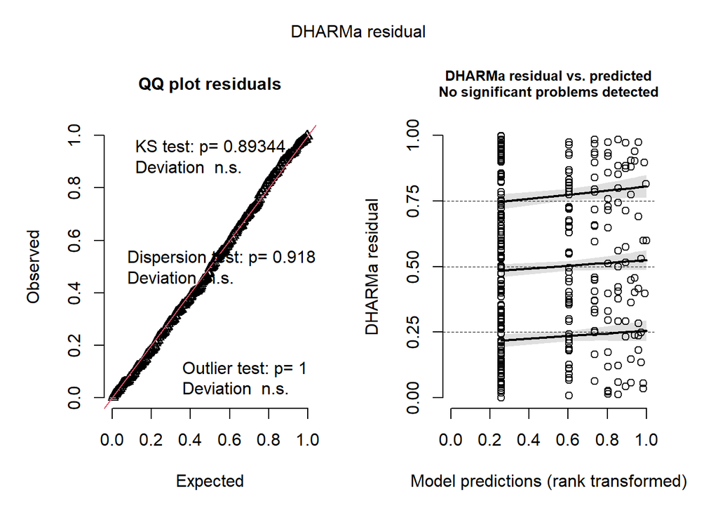

```r
# Simulando os resíduos a partir do modelo escolhido
resid_sim <- simulateResiduals(mod1, n = 1000)
plot(resid_sim)
```

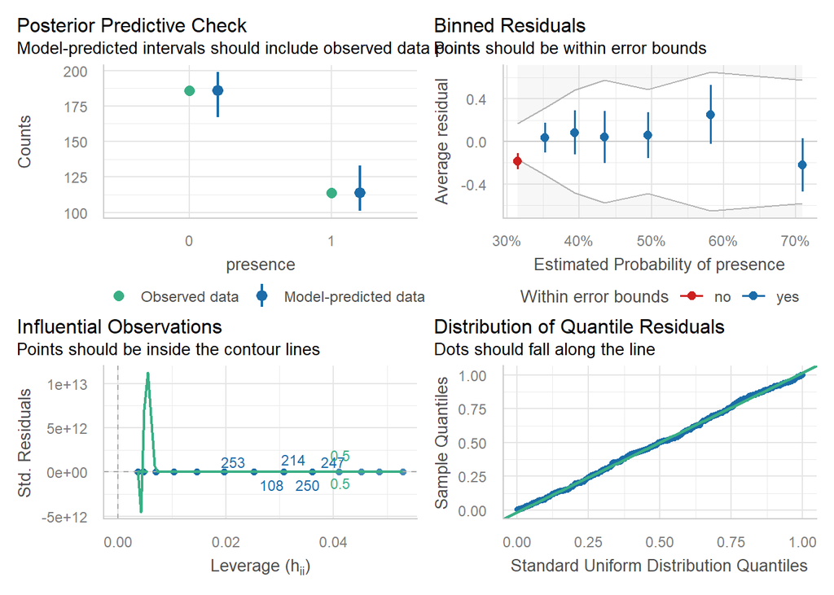

```r
# Diagnóstico completo do modelo
check_model(mod1)
```

```r
# Teste de autocorrelação
check_autocorrelation(mod1)
# Teste de overdispersion
check_overdispersion(mod1)
```

[output not shown]

```
## # Overdispersion test
##
##  dispersion ratio = 1.008
##           p-value = 0.816
```

## 8 Análise dos resultados

```r
summary(mod1)
```

```
##
## Call:
## glm(formula = presence ~ pprim_ssite, family = binomial(link = "logit"),
##     data = dados)
##
## Coefficients:
##              Estimate Std. Error z value Pr(>|z|)
## (Intercept) -0.780455   0.145811  -5.353 8.67e-08 ***
## pprim_ssite  0.034692   0.009729   3.566 0.000363 ***
## ---
## Signif. codes:  0 '***' 0.001 '**' 0.01 '*' 0.05 '.' 0.1 ' ' 1
##
## (Dispersion parameter for binomial family taken to be 1)
##
##     Null deviance: 398.44  on 299  degrees of freedom
## Residual deviance: 384.31  on 298  degrees of freedom
## AIC: 388.31
##
## Number of Fisher Scoring iterations: 4
```

```r
# Calcular Odds Ratios
exp(coef(mod1))
```

```
## (Intercept) pprim_ssite
##   0.4581974   1.0353012
```